# Лабораторная работа 5. Основы анализа данных NumPy и Matplotlib.

# Часть 1. NumPy

При решении научных задач с помощью численных методов зачастую приходится иметь дело с большими массивами данных в виде массивов и матриц. Стандартные средства Python (например, использование списков для хранения данных и прямой перебор элементов с помощью циклов) плохо подходят для таких задач, так как будут работать крайне медленно, в отличие от программ на компилируемых языках (Fortran, С). Пакет NumPy (http://www.numpy.org/) — это основной пакет, исполь¬зуемый в научных вычислениях в Python. NumPy предназначен для эф¬фективной работы с многомерными массивами, в том числе для эффек¬тивного применения математических операций к массивам и матрицам и их модификации без прямого перечисления элементов массивов. Поми¬мо этого NumPy обладает и другими возможностями — линейная алгеб¬ра, удобный ввод/вывод в файлы, моделирование случайных величин, быстрое преобразование Фурье, объединение программ на Fortran и С и другое (подробнее см. оф. сайт), поэтому важно изучить возможно¬сти данной библиотеки как можно лучше.

1. Внимательно изучите следующий урок по NumPy: http://scipy.github.io/old-wiki/pages/Tentative_NumPy_Tutorial.
2. Изучите официальное руководство пользователя https://docs.scipy.org/doc/numpy/user/.
3. Внимательно изучите Reference Guide (полное описание всех функ¬ций) https://docs.scipy.org/doc/numpy/reference/, именно в нем перечислены все возможности NumPy, этой ссылкой придется регу¬лярно пользоваться.

Выполните следующие задания (их много, но каждое занимает одну или несколько строк) средствами NumPy (и без использования циклов!)

Импортируйте пакет numpy под именем nр

```python
import numpy as np
```

Импортируйте пакет numpy под именем пр

Создайте вектор из 10 элементов, заполненный 0, пятый эле-мент которого равен 1.

```python
vector = np.zeros(10)
vector[4] = 1
```

Создайте вектор из 10 элементов, заполненный 0, пятый эле-мент которого равен 1.

```python
print(vector)
```

```
[0. 0. 0. 0. 1. 0. 0. 0. 0. 0.]
```

Создайте матрицу 3 на 3 со значениями от 0 до 8.

```python
matrix = np.arange(9).reshape(3, 3)
print(matrix)
```

```
[[0 1 2]
 [3 4 5]
 [6 7 8]]
```

Найдите индексы ненулевых элементов вектора [1,2,0,0,4,0].

```python
nz = np.nonzero([1, 2, 0, 0, 4, 0])
print(nz)
```

```
(array([0, 1, 4]),)
```

Объявите единичную матрицу размером 3 на 3.

```python
matrix = np.eye(3)
print(matrix)
```

```
[[1. 0. 0.]
 [0. 1. 0.]
 [0. 0. 1.]]
```

Создайте массив 10x10x10 из случайных чисел.

```python
mass = np.random.random((10,10,10))
print(mass)
```

[output not shown]

[output cut: 254 more lines]

[output not shown]

Создайте матрицу 8 на 8, заполненную 0 и 1 в шахматном порядке.

```python
matrix = np.zeros((8,8), dtype=int)
matrix[1::2,::2] = 1
matrix[::2,1::2] = 1
print(matrix)
```

```
[[0 1 0 1 0 1 0 1]
 [1 0 1 0 1 0 1 0]
 [0 1 0 1 0 1 0 1]
 [1 0 1 0 1 0 1 0]
 [0 1 0 1 0 1 0 1]
 [1 0 1 0 1 0 1 0]
 [0 1 0 1 0 1 0 1]
 [1 0 1 0 1 0 1 0]]
```

Найдите произведение матриц 5x3 на 3x2 (см. линейную ал-гебру) .

```python
Z = np.dot(np.ones((5,3)), np.ones((3,2)))
print(Z)
```

```
[[3. 3.]
 [3. 3.]
 [3. 3.]
 [3. 3.]
 [3. 3.]]
```

Создайте матрицу, в каждом ряду которой стоят числа от 0 до 8 (используйте сложение матрицы с вектором).

```python
matrix = np.zeros((9, 9))
print(matrix)
print('------------------------------------')
matrix += np.arange(0, 9)
print(matrix)
```

```
[[0. 0. 0. 0. 0. 0. 0. 0. 0.]
 [0. 0. 0. 0. 0. 0. 0. 0. 0.]
 [0. 0. 0. 0. 0. 0. 0. 0. 0.]
 [0. 0. 0. 0. 0. 0. 0. 0. 0.]
 [0. 0. 0. 0. 0. 0. 0. 0. 0.]
 [0. 0. 0. 0. 0. 0. 0. 0. 0.]
 [0. 0. 0. 0. 0. 0. 0. 0. 0.]
 [0. 0. 0. 0. 0. 0. 0. 0. 0.]
 [0. 0. 0. 0. 0. 0. 0. 0. 0.]]
------------------------------------
[[0. 1. 2. 3. 4. 5. 6. 7. 8.]
 [0. 1. 2. 3. 4. 5. 6. 7. 8.]
 [0. 1. 2. 3. 4. 5. 6. 7. 8.]
 [0. 1. 2. 3. 4. 5. 6. 7. 8.]
 [0. 1. 2. 3. 4. 5. 6. 7. 8.]
 [0. 1. 2. 3. 4. 5. 6. 7. 8.]
 [0. 1. 2. 3. 4. 5. 6. 7. 8.]
 [0. 1. 2. 3. 4. 5. 6. 7. 8.]
 [0. 1. 2. 3. 4. 5. 6. 7. 8.]]
```

Создайте вектор длины 1000. Найдите среднее (арифметиче¬ское) значение из этих элементов.

```python
Z = np.arange(1000)
m = Z.mean()+1
print(int(m))
```

```
500
```

## Часть 2. Matplotlib

Matplotlib (http://matplotlib.org/index.html) — это библиотека для создания графиков в Python. Matplotlib позволяет строить графики любой сложности типографского качества, которые можно вставить в статью. Подробнее о возможностях см. http://matplotlib.org/users/ intro.html. Matplotlib — большой и сложный инструмент, но на прак¬тике в научных вычислениях часто пользуются частью библиотеки matplotlib .pyplot, которая имитирует построение графиков в стиле MATLAB. В качестве до¬статочно полного введения можно прочитать http://matplotlib.org/users/index.html.

На практике бывает очень трудно помнить все возможности Matplotlib, поэтому часто используют галереи готовых примеров, а потом модифи-цируют их под свои нужды. Примеры таких подборок можно найти по следующим ссылкам: • http://matplotlib.org/gallery.html • http://matplotlib.org/examples/index.html • http://wiki.scipy.org/Cookbook/Matplotlib/

Еще материалы.

1. Введение http://matplotlib.org/users/pyplot_tutorial.html
2. Введение 2 http://www.loria.fr/~rougier/teaching/matplotlib/. Изучите, как создавать графики разных типов http://www.loria. fr/~rougier/teaching/matplotlib/#other-types-of-plots.
3. Использование текста в подписях и т.д. http://matplotlib.org/ users/text_intro.html.
4. Использование математического текста http: //matplotlib. org/users/ mathtext.html.
5. Создание легенды http://matplotlib.org/users/legend_guide.html.
6. Интерактивное использование Matplotlib http: //matplotlib. org/ users/shell .html (этот пример можно использовать не только в командной строке, но и в коде для наблюдения за изменением гра¬фиков в ходе выполнения программы).

Постройте поточечный график функции. Сгенерируйте два массива для этого. Один со значениями по возрастанию (для X), второй со случайными значениями (для Y).

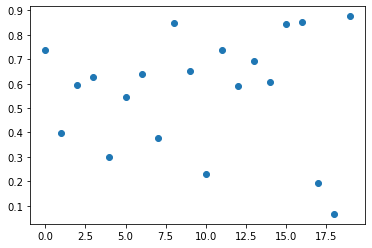

```python
import math
import matplotlib.pyplot as plt
get_ipython().run_line_magic('matplotlib', 'inline')

x = np.arange(20)
y = np.random.random(20)

print(plt.plot(x, y, 'o'))
```

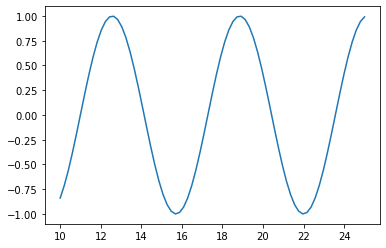

```python
x = np.linspace(10, 25, 75)
plt.plot(x, np.cos(x))
```

К графику добавьте: обозначение оси абсцисс, обозначение оси ординат, название графика, вставка легенды (текста в label).

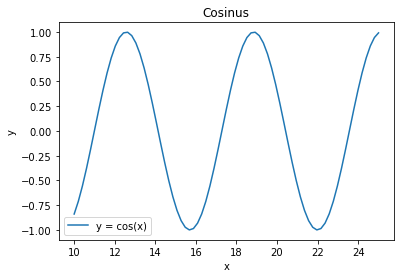

```python
plt.title("Cosinus")
plt.xlabel("x")
plt.ylabel("y")
plt.plot(x, np.cos(x), label = "y = cos(x)")
plt.legend(loc = "best")
```

Измените цвет графика на Ваш любимый.

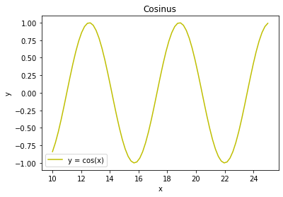

```python
plt.title("Cosinus")
plt.xlabel("x")
plt.ylabel("y")
plt.plot(x, np.cos(x), "y", label = "y = cos(x)")
plt.legend(loc = "best")
```

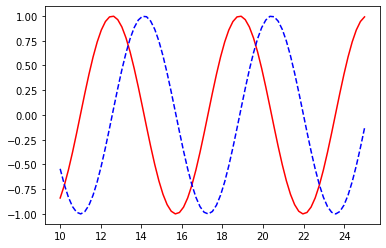

```python
a = np.linspace(10, 20, 10)
plt.plot(x, np.cos(x), "r")
plt.plot(x, np.sin(x), "b--")
```

Постройте теже графики, только для первого добавьте маркеры из красных треугольников, для второго синие круглые маркеры.

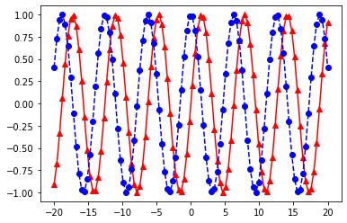

```python
x = np.linspace(-20, 20, 100)
fig, m = plt.subplots()
plt.plot(x, np.sin(x), "r", marker = "^")
plt.plot(x, np.cos(x), "b--", marker = "o")
```

Запрограмируйте сохранение графика.

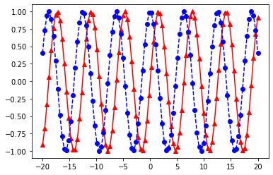

```python
x = np.linspace(-20, 20, 100)
fig, m = plt.subplots()
plt.plot(x, np.sin(x), "r", marker = "^")
plt.plot(x, np.cos(x), "b--", marker = "o")
plt.savefig('a.png')
```

# Часть 3. OpenCV

Прочитайте картинку используя opencv

[output not shown]

[figure not shown]

```python
!pip install opencv-python
import cv2
img = cv2.imread("maxresdefault.jpg")
plt.imshow(img)
```

[figure not shown]

```python
xyz_img = cv2.cvtColor(img, cv2.COLOR_BGR2XYZ)

plt.imshow(xyz_img)
```

Измените размер на 300x300

[figure not shown]

```python
img_resized = cv2.resize(img, (300, 300))

plt.imshow(img_resized)
```

Разбейте ее на 2 картинки. Сохраните.

```python
(h, w) = img.shape[:2]
left = img[:h, :w//2]
right = img[:h, w//2:]
cv2.imwrite('left.png', left)
cv2.imwrite('right.png', right)
```

```
True
```

Прочитайте 2 картинки и склейте.

[figure not shown]

```python
leftimg = cv2.imread('left.png')
rightimg = cv2.imread('right.png')
result = np.concatenate((leftimg, rightimg), axis=1)
plt.imshow(result)
```